# תרגול שישי - Logistic Regression

בתרגול זה נכיר שיטה מפוקחת ללמידה - שיטה לסיווג מידע באמצעות הסוג של המידע (להלן - הלייבל שלו).  
בתרגול הקודם ראינו איך נותנים פרדיקציה על ערך כלשהו בהתבסס על ערכים קודמים. כעת נשתמש בסט ערכי בדיד כלשהו - נניח למשל חולה (1) א בריא (0) - וננסה לחזות את הערך של דוגמיות חדשות.  
שיטות בהן משתמשים בלייבלים של הדוגמאות לצורך למידה נקראות שיטות למידה מפוקחת, וזאת בניגוד ללמידה לא מפוקחת כמו קיבוץ.

## שאלה 1

בשנת 2008 פרסם הNIH האמריקאי מידע על אודות 4238 תושבי העיר פארמינגהם במדינת מסצ'וסטס.  
המידע כלל נתונים על בריאותם של המשתתפים במחקר והאם בתוך עשור המשתתפים זוהו כסובלים ממחלות בכלי הדם הכליליים בלב. המידע זמין בקובץ 6_heart_disease_2.csv.

הערה: הדאטאסט אמיתי וניתן להורדה בצורה חופשייה. הנתונים בו שונו לצורך הדוגמה.

א. טענו את הקובץ לאובייקט מסוג DataFrame.

```python
%ls
```

```
6_heart_disease_2.csv  6_recitation_6.ipynb
```

```python
import pandas as pd

df = pd.read_csv('6_heart_disease_2.csv')
df.sample(5)
```

|  | male | age | education | currentSmoker | cigsPerDay | BPMeds | prevalentStroke | prevalentHyp | diabetes | totChol | sysBP | diaBP | BMI | heartRate | glucose | TenYearCHD |
| --- | --- | --- | --- | --- | --- | --- | --- | --- | --- | --- | --- | --- | --- | --- | --- | --- |
| 3320 | 0 | 52 | 4.0 | 0 | 0.0 | 1.0 | 0 | 1 | 0 | 264.0 | 221.0 | 112.5 | 24.80 | 74.0 | 77.0 | 1 |
| 2972 | 0 | 51 | 1.0 | 1 | 15.0 | 0.0 | 0 | 0 | 0 | 352.0 | 136.5 | 87.0 | 25.79 | 73.0 | 67.0 | 0 |
| 2374 | 1 | 45 | 1.0 | 0 | 0.0 | 0.0 | 0 | 1 | 0 | 218.0 | 133.0 | 87.0 | 31.90 | 88.0 | 115.0 | 0 |
| 3786 | 1 | 47 | 1.0 | 1 | 30.0 | 0.0 | 0 | 0 | 0 | 277.0 | 137.0 | 86.0 | 26.25 | 75.0 | 85.0 | 0 |
| 272 | 1 | 62 | 4.0 | 0 | 0.0 | 0.0 | 0 | 0 | 0 | 273.0 | 129.0 | 83.0 | 25.49 | 63.0 | 70.0 | 0 |

```python
df.describe().T
```

|  | count | mean | std | min | 25% | 50% | 75% | max |
| --- | --- | --- | --- | --- | --- | --- | --- | --- |
| male | 4238.0 | 0.429212 | 0.495022 | 0.00 | 0.00 | 0.0 | 1.000 | 1.0 |
| age | 4238.0 | 49.584946 | 8.572160 | 32.00 | 42.00 | 49.0 | 56.000 | 70.0 |
| education | 4133.0 | 1.978950 | 1.019791 | 1.00 | 1.00 | 2.0 | 3.000 | 4.0 |
| currentSmoker | 4238.0 | 0.494101 | 0.500024 | 0.00 | 0.00 | 0.0 | 1.000 | 1.0 |
| cigsPerDay | 4209.0 | 9.003089 | 11.920094 | 0.00 | 0.00 | 0.0 | 20.000 | 70.0 |
| BPMeds | 4185.0 | 0.029630 | 0.169584 | 0.00 | 0.00 | 0.0 | 0.000 | 1.0 |
| prevalentStroke | 4238.0 | 0.005899 | 0.076587 | 0.00 | 0.00 | 0.0 | 0.000 | 1.0 |
| prevalentHyp | 4238.0 | 0.310524 | 0.462763 | 0.00 | 0.00 | 0.0 | 1.000 | 1.0 |
| diabetes | 4238.0 | 0.025720 | 0.158316 | 0.00 | 0.00 | 0.0 | 0.000 | 1.0 |
| totChol | 4188.0 | 236.721585 | 44.590334 | 107.00 | 206.00 | 234.0 | 263.000 | 696.0 |
| sysBP | 4238.0 | 138.430746 | 28.790759 | 83.50 | 118.00 | 131.0 | 153.000 | 335.0 |
| diaBP | 4238.0 | 82.893464 | 11.910850 | 48.00 | 75.00 | 82.0 | 89.875 | 142.5 |
| BMI | 4219.0 | 25.802008 | 4.080111 | 15.54 | 23.07 | 25.4 | 28.040 | 56.8 |
| heartRate | 4237.0 | 75.878924 | 12.026596 | 44.00 | 68.00 | 75.0 | 83.000 | 143.0 |
| glucose | 3850.0 | 81.966753 | 23.959998 | 40.00 | 71.00 | 78.0 | 87.000 | 394.0 |
| TenYearCHD | 4238.0 | 0.151958 | 0.359023 | 0.00 | 0.00 | 0.0 | 0.000 | 1.0 |

ב. בטבלאת הנתונים עמודה אחת לקיומה של מחלת לב - TenYearCHD ושש עמודות של משתנים רציפים.  
עבור כל זוג משתנים רציפים צרו תרשים המתאר את התפלגות הדגימות כתלות בשני המשתנים. על צבע הדגימה לשקף את סוג הדגימה - כלומר האם היא דגימה של אדם אשר לקה במחלת לב כלילית או לא.

```python
continuous = ['totChol','sysBP','diaBP','BMI','heartRate','glucose']
```

```python
!pip install seaborn
```

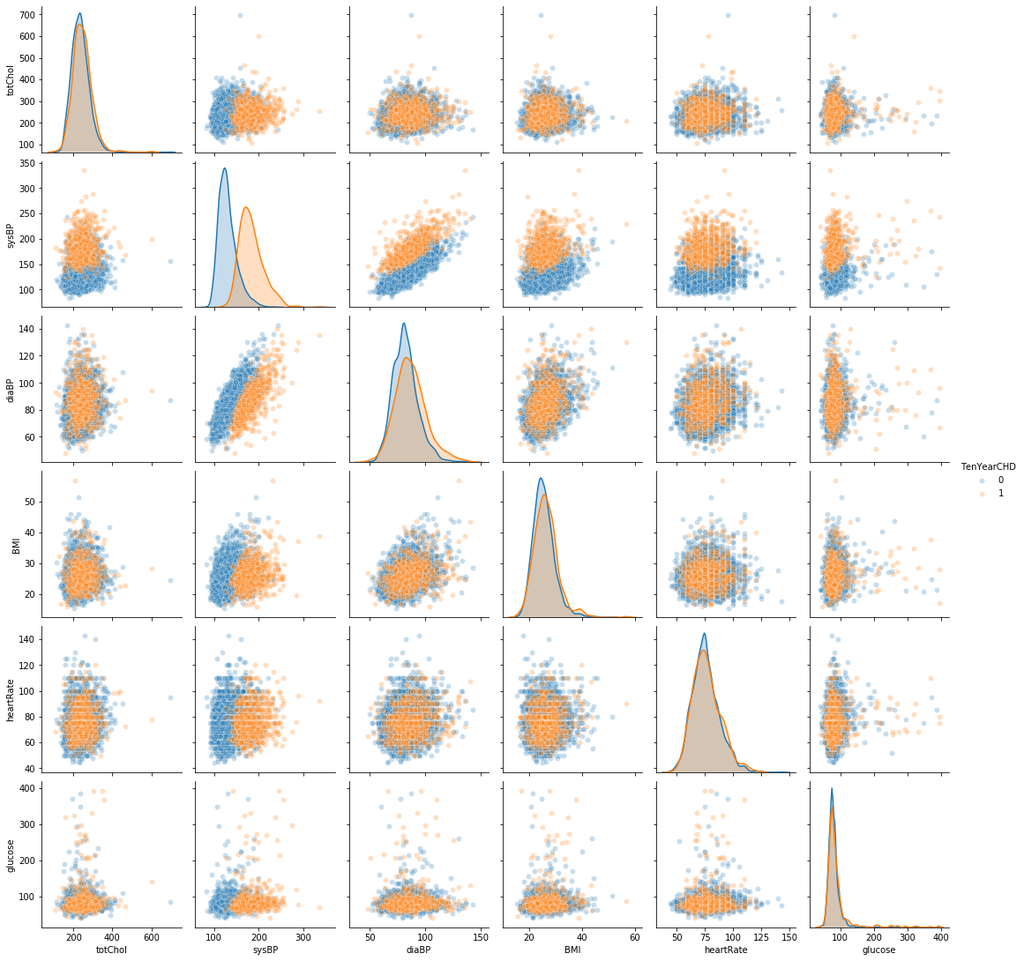

```python
import seaborn as sns

pairp = sns.pairplot(
    df[continuous + ['TenYearCHD']],
    hue='TenYearCHD',
    plot_kws={'alpha':0.25}
)
```

בתרשים למעלה אנחנו רואים את עמודות הפיצ'רים (למשל דופק בעת הגעה לרופא, אינדקס מסת גוף ועוד) אחת כתלות בשנייה. פיזור הנקודות כאן יסייע לנו לבחור פיצ'רים לשלבים הבאים.  
כמובן, ניתן היה ליצור תרשימים של שלושה פיצ'רים בתלת מימד - אבל שיטה זו של הצגה לא אינטואיטיבית ופחות נוחה.

ג. צרו מודל לינארי לניבוי האם נבדק יחלה או לא יחלה על בסיס פצ'ר אחד.  
נבחר במודל מסוג רגרסיה לוגיסטית. נשים לב לא להתבלבל עם מודל מסוג רגרסיה לינארית המשמש לפרדיקציה של ערכים בתחום הרציף.  
ברגרסיה לוגיסטית נשתמש בפונקציה מסוג סיגמואיד ונתאים אותה על הדאטא. הסיגמואיד מחזיר מספר בתחום [0,1]. נהוג להשתמש בערך הזה כהסתברות להיות במחלקה החיובית ואנחנו נסווג דוגמה כשייכת למחלקה החיובית אם ההסתברות הזו גדולה מ0.5.

[figure not shown]

המשוואות המתארות את המודל מפורטות למטה. עבור המקרה הכללי בו הפרדיקציה תלויה במשתנה אחד ממורכז סביב אפס עם שיפוע רבע:

\begin{align} \hat{y} = \frac{1}{1+e^{-z}}\\ \end{align}

במקרה החד מימדי בו המשתנה הבלתי תלוי הוא x:

\begin{align} z = a_0 + a_1x\\ \end{align}

במקרה הכללי בו הנקודה מיוצגת על ידי ווקטור של משתנים בלתי תלויים X ומקדמים A:

\begin{align} z = A^TX \end{align}

נשתמש במקרה החד מימדי כדי להדגים איך הפרמטרים למעלה משפיעים על צורת הפונקציה. משמשאל לימין - סיגמואיד סטנדרטי, a0=5 a1=1,  
a0=0 a1=5

[figure not shown]

נתחיל עם המאפיין sysBP - אשר מדווח על לחץ הדם הסיסטולי של המטופל בהגעה למרפאה.  
נבחר בו משום שבתרשים למעלה ניתן לראות הפרדה טובה של שתי המחלקות לפי המאפיין הזה.

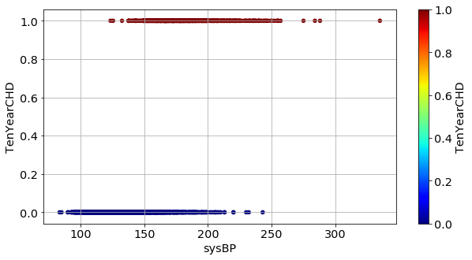

```python
import matplotlib.pyplot as plt

params = {'legend.fontsize': 'x-large',
          'figure.figsize': (10, 5),
         'axes.labelsize': 'x-large',
         'axes.titlesize':'x-large',
         'xtick.labelsize':'x-large',
         'ytick.labelsize':'x-large',
         'axes.grid':True,
         'axes.grid.which':'both'
         }
plt.rcParams.update(params)

scatp = df[['sysBP','TenYearCHD']].plot.scatter(
    x='sysBP',
    y='TenYearCHD',
    c='TenYearCHD',
    cmap='jet',
    sharex=False
)
```

כעת ננסה להתאים פונקצית סיגמואיד על הנקודות.

```python
import statsmodels.api as sm

logistic_1d = sm.Logit(
    df['TenYearCHD'],
    sm.add_constant(df['sysBP'])
)

results = logistic_1d.fit()
results.summary()
```

```
Optimization terminated successfully.
         Current function value: 0.209686
         Iterations 8
```

Logit Regression Results

| Dep. Variable: | TenYearCHD | No. Observations: | 4238 |
| --- | --- | --- | --- |
| Model: | Logit | Df Residuals: | 4236 |
| Method: | MLE | Df Model: | 1 |
| Date: | Sat, 17 Apr 2021 | Pseudo R-squ.: | 0.5079 |
| Time: | 20:22:38 | Log-Likelihood: | -888.65 |
| converged: | True | LL-Null: | -1805.8 |
| Covariance Type: | nonrobust | LLR p-value: | 0.000 |

|  | coef | std err | z | P>\|z\| | [0.025 | 0.975] |
| --- | --- | --- | --- | --- | --- | --- |
| const | -14.5705 | 0.490 | -29.761 | 0.000 | -15.530 | -13.611 |
| sysBP | 0.0835 | 0.003 | 27.845 | 0.000 | 0.078 | 0.089 |

גם כאן, כמו ברגרסיה לינארית, אנחנו מקבלים מקדמים המתאימים למקדם החופשי ולמשתנה לפיו ביצענו את הרגרסיה.  
ננסה להבין את המשמעות של מה שקיבלנו. לצורך כך נשרטט את הפונקציה יחד עם הנקודות המקוריות ולצידם נשרטט את .הנקודות לפי התחזית שלהן

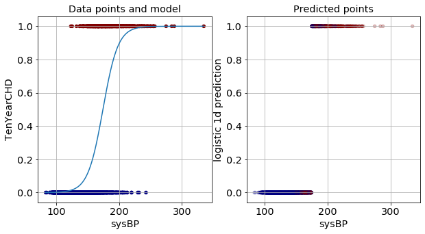

```python
fig, ax = plt.subplots(1,2)

scatp = df[['sysBP','TenYearCHD']].plot.scatter(
    x='sysBP',
    y='TenYearCHD',
    c='TenYearCHD',
    cmap='jet',
    sharex=False,
    ax=ax[0],
    colorbar=False,
    title='Data points and model'
)

logitp = ax[0].plot(
    df['sysBP'].sort_values(),
    results.predict(sm.add_constant(df['sysBP'].sort_values())),
)

df['logistic 1d prediction'] = (results.predict(sm.add_constant(df['sysBP'])) > 0.5).astype(int)

predp = df[['sysBP','logistic 1d prediction','TenYearCHD']].plot.scatter(
    x='sysBP',
    y='logistic 1d prediction',
    c='TenYearCHD',
    cmap='jet',
    sharex=False,
    ax=ax[1],
    colorbar=False,
    title='Predicted points',
    alpha=0.25
)
```

ג. מה טיב הסיווג?

נכיר כעת את הקונספט של confusion matrix. הטבלה מתארת כמה מתוך חברי המחלקה סווגו תחת לייבל כזה או אחר של המסווג.  
אמנם ראינו טבלאות כאלה בעבר אבל ראינו אותן בהקשר של למידה לא מפוקחת, ושם אמרנו שאין משמעות לשמות המקבצים לכן אין משמעות להשמה על העמודה המתאימה. כאן יש משמעות להשמה הזו מכיוון שזו הפרדיקציה למחלקה. מכאן נובע שהמקרה האידאלי הוא קבלת מטריצה אלכסונית.

```python
CM = pd.DataFrame(
    df.groupby(['TenYearCHD','logistic 1d prediction']).size(),
    columns=['# of subjects']
)

CM.unstack()
```

| logistic 1d prediction TenYearCHD | # of subjects 0 | # of subjects 1 |
| --- | --- | --- |
| 0 | 3456 | 138 |
| 1 | 274 | 370 |

מתוך המטריצה ניתן לגזור מדדי טיב על המודל שלנו. נכיר כעת אחד מהם - הדיוק. אופן החישוב שלו הוא סכום המספרים על האלכסון לחלק בסכום המטריצה כולה. לשמחתינו המדד הזה מיושם עבורינו.

```python
from sklearn import metrics

metrics.accuracy_score(
    df['TenYearCHD'],
    df['logistic 1d prediction']
)
```

```
0.902784332232185
```

ד. צרו מודל לינארי לניבוי האם נבדק יחלה או לא על בסיס שני פיצ'רים.

תחילה נבחר פיצ'רים - על בסיס התרשים למעלה נבחר בלחץ הדם הסיסטואלי כפונקציה של לחץ הדם הדיאסטולי. נשרטט את הנקודות על המישור כדי לבחון את ההתפלגות.

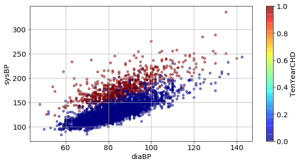

```python
scatp = df[['sysBP','diaBP','TenYearCHD']].plot.scatter(
    x='diaBP',
    y='sysBP',
    c='TenYearCHD',
    cmap='jet',
    sharex=False,
    alpha=0.5
)
```

במודל דו-מימדי יהיו לנו שני משתנים בלתי תלויים וה"גובה" של הפונקציה (מאפס ועד אחת) יהיה משתנה בפני עצמו:

\begin{align} \hat{y} = \frac{1}{1+e^{-z}}\\ z = a_0 + a_1x + a_2y\\ \end{align}

```python
logistic_1d = sm.Logit(
    df['TenYearCHD'],
    sm.add_constant(df[['diaBP','sysBP']])
)

results = logistic_1d.fit()
results.summary()
```

```
Optimization terminated successfully.
         Current function value: 0.113214
         Iterations 9
```

Logit Regression Results

| Dep. Variable: | TenYearCHD | No. Observations: | 4238 |
| --- | --- | --- | --- |
| Model: | Logit | Df Residuals: | 4235 |
| Method: | MLE | Df Model: | 2 |
| Date: | Sat, 17 Apr 2021 | Pseudo R-squ.: | 0.7343 |
| Time: | 20:22:40 | Log-Likelihood: | -479.80 |
| converged: | True | LL-Null: | -1805.8 |
| Covariance Type: | nonrobust | LLR p-value: | 0.000 |

|  | coef | std err | z | P>\|z\| | [0.025 | 0.975] |
| --- | --- | --- | --- | --- | --- | --- |
| const | -9.0277 | 0.636 | -14.184 | 0.000 | -10.275 | -7.780 |
| diaBP | -0.2372 | 0.012 | -19.567 | 0.000 | -0.261 | -0.213 |
| sysBP | 0.1760 | 0.007 | 24.287 | 0.000 | 0.162 | 0.190 |

גם כעת ברצוננו לראות את הישר המפריד בין הנתונים. לצורך כך כתבתי פונקציה. אין צורך להתעכב על כל שורה בה.

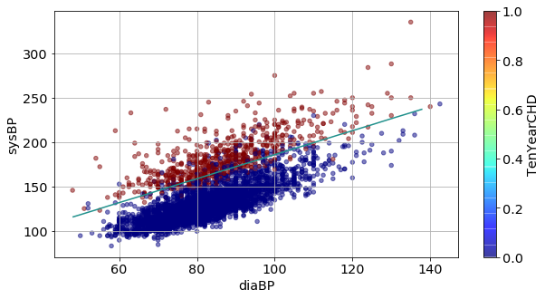

```python
import numpy as np
def decision_boundary_plot(df, x, y, results, add_c=True, p=1, level=5):
    xx, yy = np.mgrid[
        df[x].min():df[x].max():level,
        df[y].min():df[y].max():level
    ]
    grid = np.vstack([xx.ravel(), yy.ravel()]).T
    grid = pd.DataFrame(grid, columns = [x,y])**p

    if add_c:
        hh = results.predict(sm.add_constant(grid)).values.reshape(xx.shape)
    else:
        hh = results.predict(grid).values.reshape(xx.shape)

    return plt.contour(xx,yy,hh, 1)

scatp = df[['sysBP','diaBP','TenYearCHD']].plot.scatter(
    x='diaBP',
    y='sysBP',
    c='TenYearCHD',
    cmap='jet',
    sharex=False,
    alpha=0.5
)

decp = decision_boundary_plot(df, 'diaBP', 'sysBP', results)
```

ה. מה טיב הסיווג?

```python
df['logistic 2d prediction'] = (
    results.predict(sm.add_constant(df[['diaBP','sysBP']])) > 0.5
).astype(int)

CM = pd.DataFrame(
    df.groupby(['TenYearCHD','logistic 2d prediction']).size(),
    columns=['# of subjects']
)

CM.unstack()
```

| logistic 2d prediction TenYearCHD | # of subjects 0 | # of subjects 1 |
| --- | --- | --- |
| 0 | 3502 | 92 |
| 1 | 101 | 543 |

```python
metrics.accuracy_score(
    df['TenYearCHD'],
    df['logistic 2d prediction']
)
```

```
0.9544596507786692
```

ו. השתמשו במודל רגרסיה לגיסטית על מנת לסווג לפי שני הפיצ'רים - אינדקס מסת גוף ודופק.

ראשית נשרטט את שני הפיצ'רים אחד כתלות בשני:

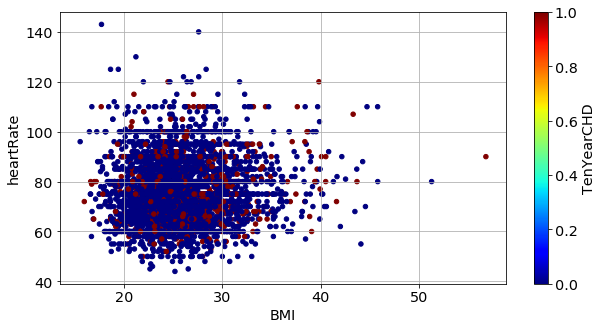

```python
scatp = df[['BMI','heartRate','TenYearCHD']].plot.scatter(
    x='BMI',
    y='heartRate',
    c='TenYearCHD',
    cmap='jet',
    sharex=False
)
```

נשים לב להתפלגות הנתונים. קיבלנו התפלגות מעין רדיאלית סביב מרכז כלשהו.  
לא ניתן להבחין בהבדל במרחק של כל מחלקה מהמרכז, ולמרות זאת משום שביקשו ננסה לסווג לפי הרדיוס מהמרחק:

\begin{align} \hat{y} = \frac{1}{1+e^{-z}}\\ z = a_1x^2 + a_2y^2\\ \end{align}

על מנת שלא להוסיף פרמטרים ללמידה כמו מיקום מרכז האליפסה במרחב, ננרמל את הנקודות שלנו תחילה:

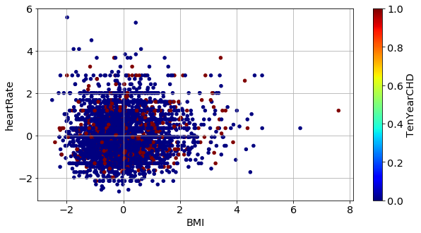

```python
df_normalized = df[['BMI','heartRate']]
df_normalized = df_normalized - df_normalized.mean()
df_normalized = df_normalized / df_normalized.std()
df_normalized['TenYearCHD'] = df['TenYearCHD']

scatp_norm = df_normalized[['BMI','heartRate','TenYearCHD']].plot.scatter(
    x='BMI',
    y='heartRate',
    c='TenYearCHD',
    cmap='jet',
    sharex=False
)
```

```python
df_normalized.describe().T
```

|  | count | mean | std | min | 25% | 50% | 75% | max |
| --- | --- | --- | --- | --- | --- | --- | --- | --- |
| BMI | 4219.0 | 2.686219e-15 | 1.000000 | -2.515129 | -0.669591 | -0.098529 | 0.548513 | 7.597340 |
| heartRate | 4237.0 | 2.347793e-17 | 1.000000 | -2.650702 | -0.655125 | -0.073082 | 0.592111 | 5.581053 |
| TenYearCHD | 4238.0 | 1.519585e-01 | 0.359023 | 0.000000 | 0.000000 | 0.000000 | 0.000000 | 1.000000 |

אכן קיבלנו ממוצע אפס (שואף אליו) וסטיית תקן אחת.  
כעת נשים לב שמספר הערכים הקיימים בכל אחד מהפיצ'רים לא זהה - חשוד לקיומם של ערכים חסרים. מודלים רבים הממומשים מראש לא מיועדים להתמודד עם המצב הזה או שמיועדים לזרוק את הערכים האלה לכן זה מה שנעשה כעת.

```python
df_normalized.dropna(inplace=True)
```

לבסוף, נתאים מודל. נשים לב במשוואה שאין צורך להוסיף משתנה חופשי.

```python
logistic_1d = sm.Logit(
    df_normalized['TenYearCHD'],
    df_normalized[['BMI','heartRate']]**2
)

results = logistic_1d.fit()
results.summary()
```

```
Optimization terminated successfully.
         Current function value: 0.574657
         Iterations 7
```

Logit Regression Results

| Dep. Variable: | TenYearCHD | No. Observations: | 4218 |
| --- | --- | --- | --- |
| Model: | Logit | Df Residuals: | 4216 |
| Method: | MLE | Df Model: | 1 |
| Date: | Sat, 17 Apr 2021 | Pseudo R-squ.: | -0.3591 |
| Time: | 20:22:43 | Log-Likelihood: | -2423.9 |
| converged: | True | LL-Null: | -1783.5 |
| Covariance Type: | nonrobust | LLR p-value: | 1.000 |

|  | coef | std err | z | P>\|z\| | [0.025 | 0.975] |
| --- | --- | --- | --- | --- | --- | --- |
| BMI | -0.3404 | 0.032 | -10.672 | 0.000 | -0.403 | -0.278 |
| heartRate | -0.6475 | 0.038 | -16.884 | 0.000 | -0.723 | -0.572 |

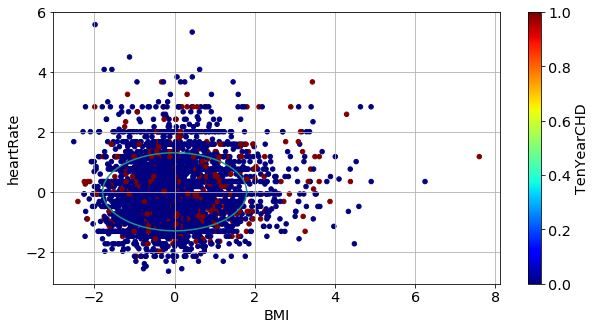

```python
df_normalized[['BMI','heartRate','TenYearCHD']].plot.scatter(
    x='BMI',
    y='heartRate',
    c='TenYearCHD',
    cmap='jet',
    sharex=False
)

decp = decision_boundary_plot(df_normalized, 'BMI', 'heartRate', results, add_c=False, p=2, level=0.1)
```

שאלה טובה שיש לשאול היא למה לעצור שם? לכאורה היינו יכולים להוסיף למודל ערכים מסדר ראשון ולקבל רמת סיבוכיות יותר גבוהה ובאופן דומה ערכים מסדר גבוה

[figure not shown]

באופן תאורטי היינו יכולים להתאים כל צורה אך מה הסכנה? אופברפיט.